# Pre-processing with phyloseq - Anglerfish

Griffin Patel

2026-04-28

```r
knitr::opts_chunk$set(echo = TRUE,
                      fig.align = "center",
                      fig.path = "../figures/03_PreProcessing")
```

# Goals

The goal with this file is to pre-process any other contaminants and unexpected ASVs from our sample. We will need to:

1. Remove any contaminating ASVs that are **chloroplasts**.
2. Remove ASVs that are **mitochondria**.
3. Evaluate any ASVs from the **negative controls**. Then, remove negative controls.
4. Evaluate the mock community or **positive control** to learn the accuracy of sequencing.
5. Check for **reverse complements**.
6. Check the **sequencing depth** of samples. Remove samples that obviously have too few reads.
7. Add the metadata for this dataset only if needed.
8. Write a `preprocessed_physeq` to be used in the next step of our workflow.

## Input

Here, we will start with the phyloseq object that we created in 02_AssignASVsAnglerfish.Rmd

1. **Raw phyloseq object**: We will need `data/02_AssignASVs_Lecture/raw_physeq.RData`.

## Output

1. We will write out a complex R data object known as an **S4** object, which in this case is known as a phyloseq output. We will store this in `data/03_PreProcessing/preprocessed_physeq.RData`.

# Set up the Environment

## Set the seeds and threads

```r
# Set the seed for reproducibility
set.seed(238428)
```

## Timing of this script

```r
# What time did we start running this script?
start_time <- Sys.time()
```

## Load packages

```r
# Load packages
pacman::p_load(devtools, phyloseq, Biostrings, tidyverse, dada2, patchwork,
               ggpubr, rstatix, install = FALSE)
```

# Load Phyloseq Data

```r
# Load the data
load("data/02_AssignASVs_Lecture/raw_physeq.RData")

# Look at the data
raw_physeq
```

```
## phyloseq-class experiment-level object
## otu_table()   OTU Table:         [ 8788 taxa and 117 samples ]
## sample_data() Sample Data:       [ 117 samples by 35 sample variables ]
## tax_table()   Taxonomy Table:    [ 8788 taxa by 7 taxonomic ranks ]
```

# Clean up the data

**Chloroplasts** and **mitochondria** need to be removed from 16S datasets because they contain their own 16S rRNA genes, which are evolutionarily derived from bacteria. These organelles can be unintentionally amplified during PCR, especially in host-associated samples, leading to misleading results by inflating microbial diversity.

Removing these sequences ensures the analysis reflects true bacterial and archaeal diversity in the sample.

## 1. Remove Chloroplasts

```r
# Make new physeq without chloroplasts
noChloros_physeq <-
  raw_physeq %>%
  # rm chloroplasts, which are Order
  subset_taxa(Order != "Chloroplast" | is.na(Order))

# How many taxa were chloroplasts?
num_chloro_ASVs <- ntaxa(raw_physeq) - ntaxa(noChloros_physeq)
num_chloro_ASVs
```

```
## [1] 200
```

There were 200 ASVs that were chloroplasts.

## 2. Remove Mitochondria

```r
# remove mitochondria
noChlorosMitos_physeq <-
  noChloros_physeq %>%
  subset_taxa(Family != "Mitochondria" | is.na(Family))

# How many mitochondrial ASVs?
num_mito_ASVs <- ntaxa(noChloros_physeq) - ntaxa(noChlorosMitos_physeq)
num_mito_ASVs
```

```
## [1] 27
```

```r
# Let's take a quick look
noChlorosMitos_physeq
```

```
## phyloseq-class experiment-level object
## otu_table()   OTU Table:         [ 8561 taxa and 117 samples ]
## sample_data() Sample Data:       [ 117 samples by 35 sample variables ]
## tax_table()   Taxonomy Table:    [ 8561 taxa by 7 taxonomic ranks ]
```

There were 27 ASVs that were mitochondria in the data set.

INTERPRETATION #1: How many chloroplast and/or mitochondrial ASVs in your dataset? Does this seem reasonable?: A total of 227 ASVs were removed as chloroplast and/or mitochondrial sequences, because the dataset decreased from 8788 taxa in the raw phyloseq object to 8561 taxa after chloroplast and mitochondrial filtering. This seems reasonable, since some mitochondria and chloroplast sequences would likely get sequenced by accident, but it shouldn’t be a significant amount. Removing these ASVs should improve the accuracy of the downstream analysis. Around 97% of sequences remained after chloroplast and mitochondrial sequences were removed, which seems like a fair amount of error, but still good to have removed.

```r
# How many total asvs were removed from chloros and mitos?
ntaxa(raw_physeq) - ntaxa(noChlorosMitos_physeq)
```

```
## [1] 227
```

```r
# proportion of asvs kept?
ntaxa(noChlorosMitos_physeq)/ntaxa(raw_physeq)
```

```
## [1] 0.9741693
```

# Evaulate and remove the control samples

Now, let’s take a look at the negative controls and then make a decision about whether or not to remove the ASVs that we found in our controls.

## 3. Negative Controls

```r
# Pull metadata
metadata_df <-
  noChlorosMitos_physeq %>%
  sample_data() %>%
  data.frame()

# Make sure names exists
if(!("names" %in% colnames(metadata_df))){
  metadata_df$names <- rownames(metadata_df)
}

# Detect likely negative controls
neg_control_samples <- unique(c(
  rownames(metadata_df)[grepl("control|blank|ntc|negative|water", rownames(metadata_df), ignore.case = TRUE)],
  unlist(lapply(metadata_df, function(x) {
    rownames(metadata_df)[grepl("control|blank|ntc|negative|water", as.character(x), ignore.case = TRUE)]
  }))
))

neg_control_samples <- neg_control_samples[!is.na(neg_control_samples)]
neg_control_samples
```

```
## character(0)
```

```r
length(neg_control_samples)
```

```
## [1] 0
```

### 3a. Evaluate Negative Control ASVs in Samples vs Controls

```r
if(length(neg_control_samples) > 0){

  # Create a phyloseq object with only negative controls
  neg_control_physeq <-
    noChlorosMitos_physeq %>%
    subset_samples(., names %in% neg_control_samples) %>%
    # force remove ASVs with 0 counts
    prune_taxa(taxa_sums(.) > 0, .)

  # Let's take a look
  neg_control_physeq

  # vector of negative control asvs
  neg_control_ASVs <- taxa_names(neg_control_physeq)

  # Visualize raw abundance values of control ASVs
  neg_control_physeq %>%
    plot_bar(., "ASV", fill = "ASV")

} else {
  message("No negative controls detected in this dataset. Skipping negative control evaluation.")
}
```

```
## No negative controls detected in this dataset. Skipping negative control evaluation.
```

### 3b. Evaluate Negative Control ASVs in Samples vs Controls

```r
if(length(neg_control_samples) > 0){

  # Add Sample_or_Control if missing
  metadata_df2 <-
    noChlorosMitos_physeq %>%
    sample_data() %>%
    data.frame()

  if(!("Sample_or_Control" %in% colnames(metadata_df2))){
    metadata_df2$Sample_or_Control <- ifelse(metadata_df2$names %in% neg_control_samples, "Control", "Sample")
    rownames(metadata_df2) <- metadata_df2$names
    sample_data(noChlorosMitos_physeq) <- metadata_df2
  }

  # Make new phyloseq object with only the control ASVs and ALL samples
  neg_controlASV_physeq <-
    noChlorosMitos_physeq %>%
    subset_taxa(., ASV %in% neg_control_ASVs)

  # Inspect it
  neg_controlASV_physeq

  # Plot Abundances of neg control ASVs in samples versus controls
  neg_controlASV_physeq %>%
    plot_bar(., "ASV", fill = "ASV", facet_grid = Sample_or_Control~.)

} else {
  message("No negative controls detected in this dataset. Skipping control comparison.")
}
```

```
## No negative controls detected in this dataset. Skipping control comparison.
```

```r
if(length(neg_control_samples) > 0){

  # Calculate the ASV relative abundance
  asv_negControls_df <-
    neg_controlASV_physeq %>%
    # agglomerate at the ASV level
    tax_glom(taxrank = "ASV") %>%
    # Melt to a long format
    psmelt()

  # Check the taxonomy of each ASV
  asv_negControls_df %>%
    dplyr::select(Kingdom:ASV) %>%
    distinct()

  dim(asv_negControls_df)

  # Statistically test
  negControl_ASV_statTest <-
    asv_negControls_df %>%
    group_by(ASV) %>%
    wilcox_test(Abundance ~ Sample_or_Control) %>%
    adjust_pvalue(method = "fdr") %>%
    add_significance() %>%
    add_xy_position(x = "Sample_or_Control", fun = "max", scales = "free") %>%
    mutate(y.position = y.position * 0.82)

  ggboxplot(
    asv_negControls_df,
    x = "Sample_or_Control", y = "Abundance",
    color = "Sample_or_Control",
    facet.by = "ASV", scales = "free_y", add = "jitter") +
    stat_pvalue_manual(negControl_ASV_statTest) +
    scale_color_manual(values = c("firebrick3", "cornflowerblue")) +
    scale_fill_manual(values = c("firebrick3", "cornflowerblue")) +
    theme_bw() +
    theme(axis.text.x = element_blank(), axis.title.x = element_blank(),
          legend.title = element_blank(), legend.position = c(0.85, 0.07))

} else {
  message("No negative controls detected in this dataset. Skipping ASV-level control statistics.")
}
```

```
## No negative controls detected in this dataset. Skipping ASV-level control statistics.
```

### 3c. Remove any ASVs in the negative controls.

```r
if(length(neg_control_samples) > 0){

  # Remove control samples only
  noControlsChlorosMitos_physeq <-
    noChlorosMitos_physeq %>%
    subset_samples(., !(names %in% neg_control_samples))

  # Inspect no controls object
  noControlsChlorosMitos_physeq

  # After filtering, how many ASVs were removed?
  total_ASVs_rm <- ntaxa(noChlorosMitos_physeq) - ntaxa(noControlsChlorosMitos_physeq)
  total_ASVs_rm

} else {

  noControlsChlorosMitos_physeq <- noChlorosMitos_physeq
  total_ASVs_rm <- 0
}
```

INTERPRETATION #2: Did your dataset have any negative controls? If so, how many ASVs did you remove? Does that seem reasonable to you? : My dataset did not appear to contain any negative controls. The code detected no negative control samples, so no control samples or ASVs were removed at this step.

# 4. Positive Controls

### What is a positive control?

A **positive control** is a sample that should produce a known result, which allows researchers to verify accuracy, detect bias or contamination, and troubleshoot technical problems.

```r
# Detect likely mock or positive controls
metadata_df3 <-
  noControlsChlorosMitos_physeq %>%
  sample_data() %>%
  data.frame()

if(!("names" %in% colnames(metadata_df3))){
  metadata_df3$names <- rownames(metadata_df3)
}

mock_samples <- unique(c(
  rownames(metadata_df3)[grepl("mock|zymo|positive|pos", rownames(metadata_df3), ignore.case = TRUE)],
  unlist(lapply(metadata_df3, function(x) {
    rownames(metadata_df3)[grepl("mock|zymo|positive|pos", as.character(x), ignore.case = TRUE)]
  }))
))

mock_samples <- mock_samples[!is.na(mock_samples)]
mock_samples
```

```
## character(0)
```

```r
length(mock_samples)
```

```
## [1] 0
```

```r
if(length(mock_samples) > 0){

  # Make mock physeq object
  mock_physeq <-
    noControlsChlorosMitos_physeq %>%
    subset_samples(., names %in% mock_samples) %>%
    prune_taxa(taxa_sums(.) > 0, .)

  # Inspect it
  mock_physeq
  tax_table(mock_physeq)

  # write us a message summarizing this
  cat("DADA2 inferred", ntaxa(mock_physeq), "ASVs present in the mock community.")

} else {
  message("No positive control or mock community detected in this dataset. Skipping mock evaluation.")
}
```

```
## No positive control or mock community detected in this dataset. Skipping mock evaluation.
```

INTERPRETATION #3: Did your dataset have a mock community? If so, what can you say about the accuracy of your sequencing run? : My dataset did not appear to contain a mock community or other positive control. The code detected no mock or positive control samples, so this step was skipped. Because there was no mock community in the dataset, I cannot directly evaluate sequencing accuracy here using a known reference community.

## Remove the mock community and it’s ASVs

```r
if(length(mock_samples) > 0){

  # Make a new phyloseq object without mock
  noControlsMock_ChlorosMitos_physeq <-
    noControlsChlorosMitos_physeq %>%
    subset_samples(., !(names %in% mock_samples))

  # Inspect
  noControlsMock_ChlorosMitos_physeq

} else {

  noControlsMock_ChlorosMitos_physeq <- noControlsChlorosMitos_physeq
}
```

# 5. Reverse Complements

## What is a reverse complement?

DNA is double-stranded, and each strand is made up of complementary bases: A pairs with T and C pairs with G.

```r
# Pull out Taxa Table
tax_table_df <-
  noControlsMock_ChlorosMitos_physeq %>%
  tax_table() %>%
  data.frame()

# Add ASV column if needed
if(!("ASV" %in% colnames(tax_table_df))){
  tax_table_df$ASV <- rownames(tax_table_df)
}

# Grab ASV Sequences and Names
asv_names <- tax_table_df$ASV
asv_seqs <- rownames(tax_table_df)

# Create empty comparison matrix
asv_rev_comp <- matrix(nrow = length(asv_seqs), ncol = length(asv_seqs))

# Fix the names in the rows and columns
rownames(asv_rev_comp) <- asv_names
colnames(asv_rev_comp) <- asv_names

# Convert sequences to Biostrings
asv_dna <- DNAStringSet(asv_seqs)

# Construct reverse complement
asv_rev_dna <- reverseComplement(asv_dna)

# Now loop through every asv sequence to check
for(i in 1:length(asv_seqs)){
  match_vec <- asv_dna[i] == asv_rev_dna
  asv_rev_comp[,i] <- match_vec
}

# Find how many TRUEs (matches) we have, divide by 2 because each pair occurs twice
cat("For", sum(asv_rev_comp) / 2, "ASVs, the reverse complement will need to be removed")
```

```
## For 0 ASVs, the reverse complement will need to be removed
```

INTERPRETATION #4: Do you have any reverse complements in your dataset? : I did not detect any reverse complements in my dataset. The reverse complement check reported 0 ASVs that would need to be removed. This suggests that the ASVs are already in a consistent orientation and that reverse-complement artifacts are not inflating diversity in this dataset.

# 6. Sequencing Depth

```r
# The current data object
noControlsMock_ChlorosMitos_physeq
```

```
## phyloseq-class experiment-level object
## otu_table()   OTU Table:         [ 8561 taxa and 117 samples ]
## sample_data() Sample Data:       [ 117 samples by 35 sample variables ]
## tax_table()   Taxonomy Table:    [ 8561 taxa by 7 taxonomic ranks ]
```

```r
# Read metadata fresh from file
metadata_df <- read.csv("/local/workdir/glp56/Anglerfish_16S/data/metadata/SraRunTable.csv",
                        stringsAsFactors = FALSE)

# Build sequencing depth table and match metadata by Run accession
seqSums_df <- data.frame(
  names = sample_names(noControlsMock_ChlorosMitos_physeq),
  TotalSeqs = sample_sums(noControlsMock_ChlorosMitos_physeq),
  stringsAsFactors = FALSE
) %>%
  mutate(Run = sub("_R1_filtered\\.fastq\\.gz$", "", names)) %>%
  left_join(metadata_df, by = "Run")

# check
dim(seqSums_df)
```

```
## [1] 117  37
```

```r
head(seqSums_df)
```

```
##                             names TotalSeqs        Run Assay.Type AvgSpotLen
## 1 SRR8438042_R1_filtered.fastq.gz     42740 SRR8438042   AMPLICON        500
## 2 SRR8438043_R1_filtered.fastq.gz      4038 SRR8438043   AMPLICON        500
## 3 SRR8438044_R1_filtered.fastq.gz     88323 SRR8438044   AMPLICON        500
## 4 SRR8438045_R1_filtered.fastq.gz     18084 SRR8438045   AMPLICON        501
## 5 SRR8438046_R1_filtered.fastq.gz     14546 SRR8438046   AMPLICON        501
## 6 SRR8438047_R1_filtered.fastq.gz     26042 SRR8438047   AMPLICON        500
##      Bases  BioProject    BioSample              BioSampleModel    Bytes
## 1 32541049 PRJNA514914 SAMN10737168 Metagenome or environmental 23340759
## 2  2432740 PRJNA514914 SAMN10737169 Metagenome or environmental  1748739
## 3 55868495 PRJNA514914 SAMN10737166 Metagenome or environmental 37795643
## 4 13581264 PRJNA514914 SAMN10737167 Metagenome or environmental  9795639
## 5 13407845 PRJNA514914 SAMN10737172 Metagenome or environmental  9790600
## 6 15129422 PRJNA514914 SAMN10737173 Metagenome or environmental 10378224
##                    Center.Name Collection_Date Consent DATASTORE.filetype
```

[output cut: 48 more lines]

```r
# Show the depth of samples
seqSums_df %>%
  dplyr::select(names, Run, TotalSeqs, isolation_source) %>%
  arrange(TotalSeqs) %>%
  head()
```

```
##                             names        Run TotalSeqs isolation_source
## 1 SRR8438128_R1_filtered.fastq.gz SRR8438128       153            gills
## 2 SRR8438054_R1_filtered.fastq.gz SRR8438054      1018             Esca
## 3 SRR8438043_R1_filtered.fastq.gz SRR8438043      4038             Esca
## 4 SRR8438097_R1_filtered.fastq.gz SRR8438097      4047             Guts
## 5 SRR8438075_R1_filtered.fastq.gz SRR8438075      4283             Esca
## 6 SRR8438068_R1_filtered.fastq.gz SRR8438068      5332         Illicium
```

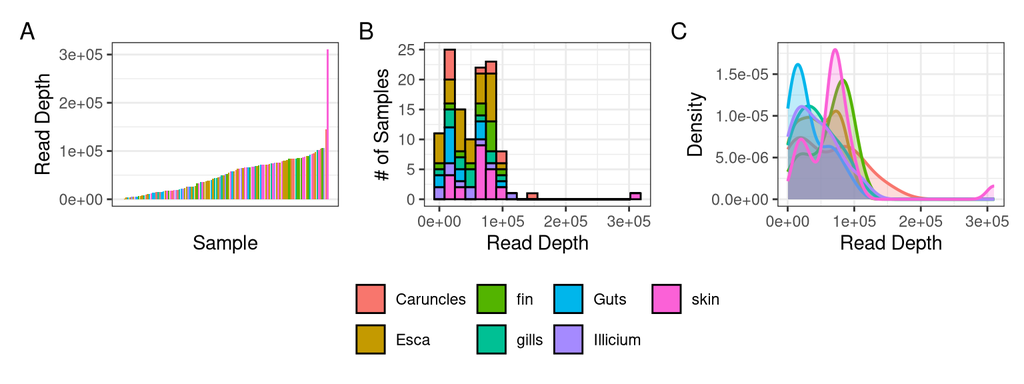

```r
# Bar plot
numSeq_bar_plot <-
  seqSums_df %>%
  arrange(TotalSeqs) %>%
  ggplot(aes(x = seq_along(names), y = TotalSeqs, fill = isolation_source)) +
  geom_col(width = 0.9, color = NA) +
  labs(y = "Read Depth", x = "Sample") +
  theme_bw() +
  theme(
    axis.text.x = element_blank(),
    axis.ticks.x = element_blank(),
    panel.grid.major.x = element_blank(),
    panel.grid.minor.x = element_blank(),
    legend.position = "none"
  )

# Histogram
numSeq_hist_plot <-
  seqSums_df %>%
  ggplot(aes(x = TotalSeqs, fill = isolation_source)) +
  geom_histogram(color = "black", bins = 20) +
  labs(y = "# of Samples", x = "Read Depth") +
  theme_bw() +
  theme(legend.position = "bottom",
        legend.title = element_blank())

# Density plot
numSeq_density_plot <-
  seqSums_df %>%
  ggplot(aes(TotalSeqs, fill = isolation_source, color = isolation_source)) +
  geom_density(alpha = 0.25, linewidth = 0.8) +
  labs(x = "Read Depth", y = "Density") +
  theme_bw() +
  theme(legend.position = "none")

# Put it all together
numSeq_bar_plot + numSeq_hist_plot + numSeq_density_plot +
  plot_annotation(tag_levels = "A")
```

INTERPRETATION #5: What can you conclude about your sequencing depths? What are your sample distributions? Do you have “enough” reads? Are there any samples that should be removed at this step? : There is substantial variation in sequencing depth across samples, but most samples cluster at low to moderate read depths, with a smaller number of samples having much higher sequencing depth. The minimum sequencing depth was 153 reads, and the next few lowest-depth samples had 1,018, 4,038, 4,047, 4,283, and 5,332 reads. Most samples fall well above these lowest values, and the isolation source categories are all represented across the dataset. Overall, most samples appear to have enough reads for downstream analysis, but there are a few very low-depth samples. I think overall, I have enough reads after these steps.

## Remove samples with few reads

```r
# What's the min seq depth?
min(sample_sums(noControlsMock_ChlorosMitos_physeq))
```

```
## [1] 153
```

```r
# Keep all samples for now
preprocessed_physeq <- noControlsMock_ChlorosMitos_physeq

# What's the new min seq depth?
min(sample_sums(preprocessed_physeq))
```

```
## [1] 153
```

```r
# Final check of the sequencing depth for now
seqSums_df %>%
  dplyr::select(names, TotalSeqs) %>%
  arrange(TotalSeqs)
```

```
##                               names TotalSeqs
## 1   SRR8438128_R1_filtered.fastq.gz       153
## 2   SRR8438054_R1_filtered.fastq.gz      1018
## 3   SRR8438043_R1_filtered.fastq.gz      4038
## 4   SRR8438097_R1_filtered.fastq.gz      4047
## 5   SRR8438075_R1_filtered.fastq.gz      4283
## 6   SRR8438068_R1_filtered.fastq.gz      5332
## 7   SRR8438153_R1_filtered.fastq.gz      5546
## 8   SRR8438060_R1_filtered.fastq.gz      5837
## 9   SRR8438129_R1_filtered.fastq.gz      5986
## 10  SRR8438135_R1_filtered.fastq.gz      7110
## 11  SRR8438093_R1_filtered.fastq.gz      7430
## 12  SRR8438152_R1_filtered.fastq.gz      8480
## 13  SRR8438136_R1_filtered.fastq.gz      8507
## 14  SRR8438134_R1_filtered.fastq.gz      9137
```

[output cut: 103 more lines]

# 7. Add some metadata

*Likely, you do not need to do this step as you already have the data in your metadata! If so, you can skip this step.*

```r
metadata_df <-
  preprocessed_physeq %>%
  sample_data() %>%
  data.frame()

if(!("names" %in% colnames(metadata_df))){
  metadata_df$names <- rownames(metadata_df)
}

num_seqs_df <-
  preprocessed_physeq %>%
  sample_sums() %>%
  data.frame() %>%
  rownames_to_column(var = "names")

colnames(num_seqs_df)[2] <- "Sequencing_Depth"

metadata_df2 <-
  metadata_df %>%
  left_join(num_seqs_df, by = "names")

rownames(metadata_df2) <- metadata_df2$names
sample_data(preprocessed_physeq) <- metadata_df2

colnames(data.frame(sample_data(preprocessed_physeq)))
```

```
##  [1] "Run"                            "Assay.Type"
##  [3] "AvgSpotLen"                     "Bases"
##  [5] "BioProject"                     "BioSample"
##  [7] "BioSampleModel"                 "Bytes"
##  [9] "Center.Name"                    "Collection_Date"
## [11] "Consent"                        "DATASTORE.filetype"
## [13] "DATASTORE.provider"             "DATASTORE.region"
## [15] "Experiment"                     "FishID"
## [17] "geo_loc_name_country"           "geo_loc_name_country_continent"
## [19] "geo_loc_name"                   "HOST"
## [21] "Instrument"                     "isolation_source"
## [23] "lat_lon"                        "Library.Name"
## [25] "LibraryLayout"                  "LibrarySelection"
## [27] "LibrarySource"                  "Organism"
## [29] "Platform"                       "ReleaseDate"
## [31] "create_date"                    "version"
## [33] "samp_collect_device"            "Sample.Name"
## [35] "SRA.Study"                      "names"
## [37] "Sequencing_Depth"
```

# 8. Write out the data

```r
dir.create("data/03_PreProcessing", recursive = TRUE, showWarnings = FALSE)

save(preprocessed_physeq, file = "data/03_PreProcessing/preprocessed_physeq.RData")
```

# Final info for Reproducibility

## Check Render Time

```r
# Take the time now that we are at the end of the script
end_time <- Sys.time()
end_time
```

```
## [1] "2026-04-28 23:28:27 EDT"
```

```r
# Echo the elapsed time
elapsed_time <- round((end_time - start_time), 3)
elapsed_time
```

```
## Time difference of 24.832 secs
```